# MATH615 Final Project - Sean Lowney

# 1 . Introduction

There are many factors that influence population health statistics, be it socioeconomic issues, i.e. access to quality healthcare or income levels, or more direct health considerations such as individual health behaviors or one’s physical environment. A series of studies performed by the CDC in the 2010s suggest that there is a significant gap in the health standards between urban and rural U.S. citizens.<sup>1</sup> With this in mind, the following study seeks to assess whether there are significant enough differences in the health behaviors of these populations to adequately predict a county’s urban vs rural status based on data alone.

To do this, I use a data set created by County Health Rankings, an organization under University of Wisconsin’s School of Public Health whose purpose is to accumulate population health data for the sake of informed, data driven policy making. Their model divides the influences on health outcomes into four broad categories, of which I use those defined as health behaviors to generate a logistic regression model. The following notebook will include sections on loading and manipulating the data, a series of visualizations to better understand the data set, and finally model creation, tuning, and interpretation. If a difference between the two population exists, then I should be able to use this data to classify each county as rural or urban with greater than 75% accuracy.

# 2 . R environment

```r
library(tidyverse)  #GGplot2, readr, tidyr
library(dplyr)      #Dataframe manipulation
library(readxl)     #Read in county class data
library(ROCR)       #ROC/AUC plot
library(ggpubr)     #ggboxplot

#Packages not loaded but used directly: Hmisc, broom, car
```

# 3 . Data preparation

## 3.1 . Data description

This analysis uses two data sets.  
1) National Center for Health Statistics: Urban-Rural Classification Scheme for Counties - Based on Office of Management and Budget’s of metro- and micropolitan statistical areas.<sup>2</sup>  
2) County Health Rankings: 2020 county level health statistics - selected for statistics relating to actions individuals take that affect their health.<sup>3</sup>

## 3.2 . Data loading and manipulation

The data loading and manipulation is documented as such. County classification data and health statistics are loaded, adjusted for proper data typing, and joined based on the FIPS-code, a unique county identifier. Raw values were selected and renamed for easier understanding. I then filter out columns in which more than 100 rows are NA, then remove the remaining rows with NA values and finally remove the FIPS column as it is no longer needed. This leaves me with a dataframe containing 10 features, 1 target classification value, and 3028 sample counties.

```r
#1: Load and process counties by urban-rural classification scheme
countyClass = select(read_excel("../data/countycodes.xlsx"),c('FIPS code','2013 code')) %>%
  rename(FIPS = 'FIPS code',Class = '2013 code') %>%
  mutate(classAdj = ifelse(Class <=4, "Urban","Rural"))

countyClass$FIPS = as.integer(countyClass$FIPS)
countyClass$classAdj = as.factor(countyClass$classAdj)

#2: Create vectors to select and rename target features, load data
featureSelect = c('fipscode','v009_rawvalue','v011_rawvalue','v133_rawvalue','v070_rawvalue',
                   'v132_rawvalue','v049_rawvalue','v134_rawvalue','v045_rawvalue','v139_rawvalue',
                   'v083_rawvalue','v138_rawvalue','v039_rawvalue','v147_rawvalue')

featureNames = c('FIPS','Smoking','Obesity','Food_Envi','Phys_Inactivity','Exercise_Opp',
                  'Drinking','DUI_Death','STI','Food_Insecutrity',
                  'Healthy_Food_Access','Drug_Overdose','Motor_Vehicle_Death','Life_Expectancy')

rawStats = select(read.csv("../data/socEcData2020.csv"),contains(featureSelect)) %>% filter(fipscode != 0)
colnames(rawStats) = featureNames

#3: Join county classification with other tables
joinData = rawStats %>% left_join(select(countyClass,c("FIPS","classAdj")))
#4: Tidy the joined tables
tidyData = drop_na(joinData[ , colSums(is.na(rawStats)) < 100]) %>% select(-FIPS)
cat("Dataframe dimensions -- Before: ",dim(joinData)," -- After: ",dim(tidyData))
```

```
Dataframe dimensions -- Before:  3193 15  -- After:  3028 11
```

```r
cat("\nNAs -- Before: ",sapply(joinData,function(x) sum(is.na(x)))," -- After: ",sapply(tidyData,function(x) sum(is.na(x))))
```

```
NAs -- Before:  0 0 0 19 0 6 0 35 152 0 19 1420 444 73 51  -- After:  0 0 0 0 0 0 0 0 0 0 0
```

```r
#Preview
head(tidyData)
```

|  | Smoking | Obesity | Food_Envi | Phys_Inactivity | Exercise_Opp | Drinking | DUI_Death | Food_Insecutrity | Healthy_Food_Access | Life_Expectancy | classAdj |
| --- | --- | --- | --- | --- | --- | --- | --- | --- | --- | --- | --- |
| 1 | 0.1808156 | 0.333 | 7.2 | 0.347 | 0.69130124 | 0.1502603 | 0.2678571 | 0.132 | 0.11991125 | 76.87948 | Urban |
| 2 | 0.1748903 | 0.310 | 8.0 | 0.265 | 0.73713549 | 0.1795831 | 0.3076923 | 0.116 | 0.05424427 | 78.45026 | Urban |
| 3 | 0.2199998 | 0.417 | 5.6 | 0.235 | 0.53166770 | 0.1284402 | 0.4000000 | 0.220 | 0.10739667 | 75.34193 | Rural |
| 4 | 0.1911420 | 0.376 | 7.8 | 0.335 | 0.16251364 | 0.1557004 | 0.2758621 | 0.143 | 0.02601627 | 73.57182 | Urban |
| 5 | 0.1920867 | 0.338 | 8.4 | 0.303 | 0.15634486 | 0.1423059 | 0.1944444 | 0.107 | 0.02880150 | 74.14583 | Urban |
| 6 | 0.2289466 | 0.372 | 4.3 | 0.246 | 0.02501374 | 0.1209410 | 0.6000000 | 0.248 | 0.19743351 | 73.53089 | Rural |

# 4 . Data visualization

One of the more general health defining statistics of an area is its average life expectancy. In the following block, I seek to characterize the difference in this measure for the two populations. The data is split based on classification and tested to see whether the difference in means is significant. The null hypothesis, that no difference exists between the two populations, would suggest that further exploration into these statistics are potentially unnecessary. First, an F test to compare variances is performed and passed into the T test.

```r
#Exploratory statistics
group_by(tidyData,classAdj) %>%
  summarise(
    count = n(),
    mean = mean(Life_Expectancy),
    sd = sd(Life_Expectancy)
  )
```

| classAdj | count | mean | sd |
| --- | --- | --- | --- |
| Rural | 1873 | 77.04137 | 3.122611 |
| Urban | 1155 | 78.13388 | 2.668276 |

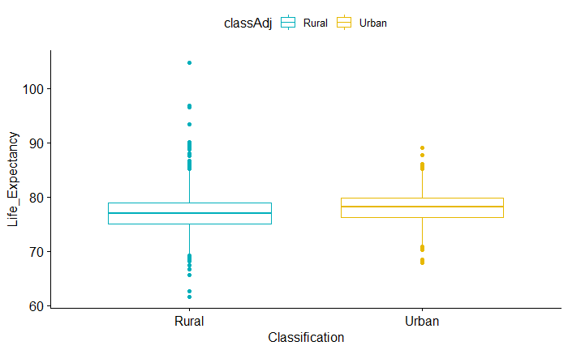

```r
#Exploratory statistics
ggboxplot(tidyData, x = "classAdj", y = "Life_Expectancy",
          color = "classAdj", palette = c("#00AFBB", "#E7B800"),
        ylab = "Life_Expectancy", xlab = "Classification")
```

```r
#Variance and T tests
var.test(Life_Expectancy ~ classAdj, data = tidyData) #Returns significant p-value showing that variance is not equal
```

```
    F test to compare two variances

data:  Life_Expectancy by classAdj
F = 1.3695, num df = 1872, denom df = 1154, p-value = 4.848e-09
alternative hypothesis: true ratio of variances is not equal to 1
95 percent confidence interval:
 1.233733 1.518326
sample estimates:
ratio of variances
          1.369539
```

```r
t.test(Life_Expectancy ~ classAdj, data = tidyData, var.equal = FALSE)
```

```
    Welch Two Sample t-test

data:  Life_Expectancy by classAdj
t = -10.246, df = 2727.2, p-value < 2.2e-16
alternative hypothesis: true difference in means between group Rural and group Urban is not equal to 0
95 percent confidence interval:
 -1.301591 -0.883420
sample estimates:
mean in group Rural mean in group Urban
           77.04137            78.13388
```

As a result of the above T test, I can reject the null hypothesis and assume that a difference in means exists between the two populations. I will now visualize some of the other data to understand the distributions. First, I used the Hmisc package to view the distribution of the whole data set. I then use GGPlot to split the data based on classification to see if there are any differences between the way certain variables are distributed among different populations.

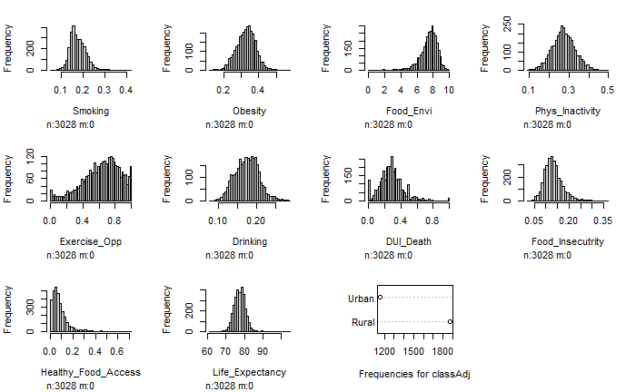

```r
Hmisc::hist.data.frame(tidyData)
```

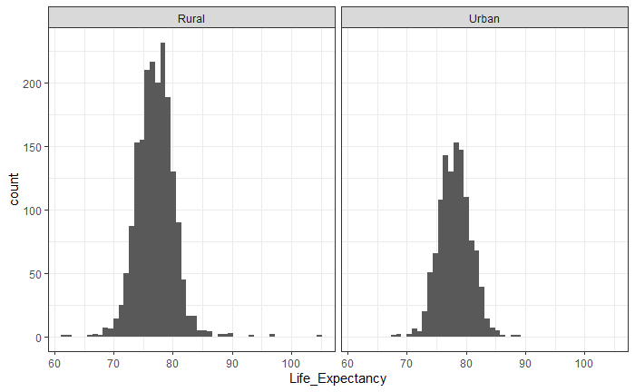

```r
ggplot(tidyData,aes(x=Life_Expectancy))+
  geom_histogram(bins=50)+
  facet_grid(~classAdj)+
  theme_bw()
```

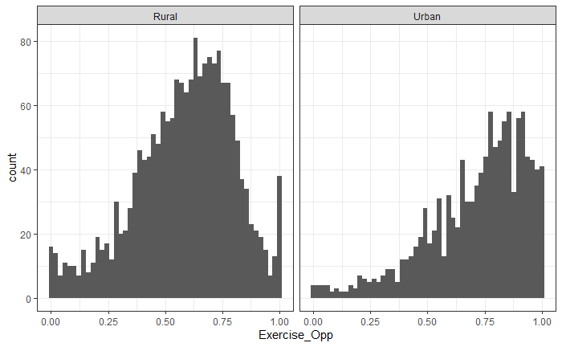

```r
ggplot(tidyData,aes(x=Exercise_Opp))+
  geom_histogram(bins=50)+
  facet_grid(~classAdj)+
  theme_bw()
```

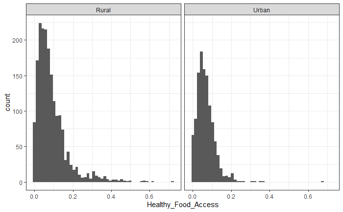

```r
ggplot(tidyData,aes(x=Healthy_Food_Access))+
  geom_histogram(bins=50)+
  facet_grid(~classAdj)+
  theme_bw()
```

I can see from the above histograms that the data appears mostly normal with several features displaying a skew to one direction. On further analysis, this skew appears consistent for both urban and rural populations and so I will continue my analysis cognizant of this fact.

# 5 . Data modeling

## 5.1 . Model description

I will now attempt to create the classification model. To do this, I will use a binomial logistic regression to predict between urban and rural classification.

## 5.2 . Model

```r
#Logistic Reg
logitModel = glm(classAdj~.,data=tidyData,family="binomial")
summary(logitModel)
```

```
Call:
glm(formula = classAdj ~ ., family = "binomial", data = tidyData)

Deviance Residuals:
    Min       1Q   Median       3Q      Max
-1.7652  -0.9649  -0.6611   1.1106   2.9554

Coefficients:
                     Estimate Std. Error z value Pr(>|z|)
(Intercept)          1.876276  14.849736   0.126  0.89945
Smoking             -2.677823   1.798859  -1.489  0.13659
Obesity              1.826879   0.958908   1.905  0.05676 .
Food_Envi           -0.255518   1.377254  -0.186  0.85282
Phys_Inactivity     -4.681698   1.045565  -4.478 7.55e-06 ***
Exercise_Opp         2.203284   0.223250   9.869  < 2e-16 ***
Drinking             2.504769   1.659074   1.510  0.13111
DUI_Death           -0.821858   0.290875  -2.825  0.00472 **
Food_Insecutrity    -4.058760  25.851573  -0.157  0.87524
Healthy_Food_Access -6.487371  12.226893  -0.531  0.59571
Life_Expectancy      0.001101   0.022412   0.049  0.96084
---
Signif. codes:  0 ‘***’ 0.001 ‘**’ 0.01 ‘*’ 0.05 ‘.’ 0.1 ‘ ’ 1

(Dispersion parameter for binomial family taken to be 1)

    Null deviance: 4025.8  on 3027  degrees of freedom
Residual deviance: 3662.2  on 3017  degrees of freedom
AIC: 3684.2

Number of Fisher Scoring iterations: 4
```

## 5.3 . Diagnostics

Before proceeding further, I need to ensure that several assumptions associated with logistic regression models are consistent with this model. The three I will test for are the existence of linearity and the lack of influential values and multicollinearity.<sup>4</sup>

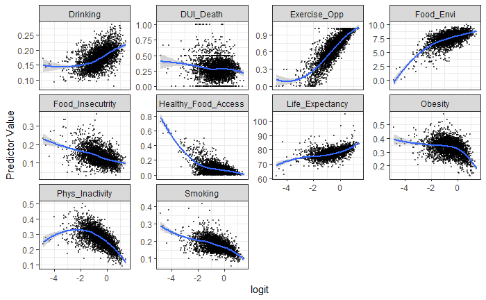

```r
#Create test prediction model for diagnostic purposes
testPrediction =  predict(logitModel, type = "response")

#Select predictors
testData = tidyData %>% select_if(is.numeric)
predictors = colnames(mydata)

#Plotting
testData = testData %>%
  mutate(logit = log(testPrediction/(1-testPrediction))) %>%
  gather(key = "predictors", value = "Predictor Value", -logit)

ggplot(testData, aes(logit, `Predictor Value`))+
  geom_point(size = 0.5, alpha = 0.5) +
  geom_smooth(method = "loess") +
  theme_bw() +
  facet_wrap(~predictors, scales = "free_y")
```

The linearity assumption holds well enough for most of the predictor variables. Certain predictors, like physical inactivity, are questionable, however the tails that interrupt the nonlinear assumptions are the result of notably fewer samples so I am willing to ignore them in this case.

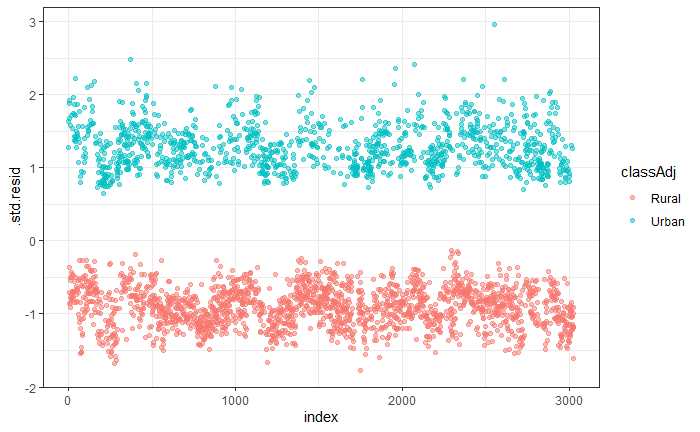

```r
#Compute scaled residuals
influentialData = broom::augment(logitModel) %>%
  mutate(index = 1:n())

#Plotting
ggplot(influentialData, aes(index, .std.resid)) +
  geom_point(aes(color = classAdj), alpha = .5) +
  theme_bw()
```

```r
#Check for influential data points
badSamples = influentialData %>% filter(abs(.std.resid) > 3) %>% nrow()
print(paste("Number of overly influential samples:",badSamples))
```

```
[1] "Number of overly influential samples: 0"
```

Data points with scaled residuals above 3 are considered possible outliers. The above analysis suggests that no such samples exists and so the assumption of no overly influential samples holds.

```r
#Test for overly correlated predictors
car::vif(logitModel)
```

```
            Smoking             Obesity           Food_Envi     Phys_Inactivity        Exercise_Opp            Drinking
           2.296080            1.640177         1065.026488            2.045436            1.275654            1.658782
          DUI_Death    Food_Insecutrity Healthy_Food_Access     Life_Expectancy
           1.037173          573.184222          310.739004            2.590039
```

By calculating the variance inflation factor, I can estimate the severity of multicollinearity among the features. Values above 5 are concerning, three of which are seen above. These three features are all food related, so a correlation between them is understandable. Of the three, food insecurity was the most confidently linear predictor, so I will remove the other two and retest.

```r
#Remove feature
tidyData2 = select(tidyData,-one_of(c("Food_Envi","Healthy_Food_Access")))

#Recreate model
logitModel2 = glm(classAdj~.,data=tidyData2,family="binomial")

#Rerun test for multicollinearity
car::vif(logitModel2)
```

```
         Smoking          Obesity  Phys_Inactivity     Exercise_Opp         Drinking        DUI_Death Food_Insecutrity
        2.307516         1.641497         1.999857         1.260419         1.632266         1.037989         1.855237
 Life_Expectancy
        2.545790
```

Much better!

# 6 . Results

## 6.1 . Model interpretation

I will now run and test the accuracy of the model. First, I will split the data into training and test set. Then I will run an ANOVA test to compare it to the null model, test the prediction accuracy on the test set.

```r
#Train/Test Split
numSamples = nrow(tidyData2)
train = tidyData2[1:round(0.8*numSamples),]
test = tidyData2[(numSamples-0.2*numSamples+1):numSamples,]

#Run Model
finalModel = glm(classAdj~.,data=train,family="binomial")

#ANOVA
anova(finalModel, test="Chisq")
```

```
Analysis of Deviance Table

Model: binomial, link: logit

Response: classAdj

Terms added sequentially (first to last)

                 Df Deviance Resid. Df Resid. Dev  Pr(>Chi)
NULL                              2421     3198.2
Smoking           1   96.857      2420     3101.3 < 2.2e-16 ***
Obesity           1   14.599      2419     3086.7  0.000133 ***
Phys_Inactivity   1   47.453      2418     3039.2 5.633e-12 ***
Exercise_Opp      1  108.953      2417     2930.3 < 2.2e-16 ***
Drinking          1    0.717      2416     2929.6  0.397161
DUI_Death         1   10.362      2415     2919.2  0.001286 **
Food_Insecutrity  1    0.015      2414     2919.2  0.902743
Life_Expectancy   1    2.437      2413     2916.8  0.118478
---
Signif. codes:  0 ‘***’ 0.001 ‘**’ 0.01 ‘*’ 0.05 ‘.’ 0.1 ‘ ’ 1
```

```r
#Prediction Accuracy
results = predict(finalModel,test,type='response')
results = ifelse(results > 0.5,"Urban","Rural")

error = mean(results != test$classAdj)
print(paste('Accuracy: ',round(1-error,4)*100,'%',sep=""))
```

```
[1] "Accuracy: 65.62%"
```

## 6.2 . Model visualization

Because visualizing a logistic regression model with several predictor variables isn’t very viable, I’ve chosen to show it as the ROC plot. Here I ROC plot as a function of true and false positive rates. An AUC of closer to 1 is ideal.

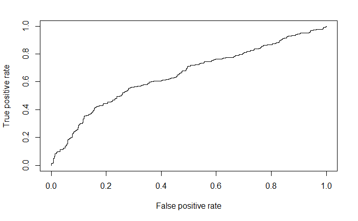

```r
#Predict and plot AUC curve
pred = predict(finalModel, test, type="response")
testPred = prediction(pred, test$classAdj)
rocPlot = performance(testPred, measure = "tpr", x.measure = "fpr")
plot(rocPlot)
```

```r
#Calc area under curve
auc = performance(pr, measure = "auc")
auc = auc@y.values[[1]]
auc
```

```
[1] 0.6494341
```

# 7 . Discussion and conclusion

Unfortunately, this model was not able to obtain the predictive ability I was aiming for. Although the accuracy, was around 65%, which suggest some measure of predictability given the factors I used, such a model can not be used reliably. This suggests one of two things: either that the differences between urban and rural populations are not differentiable, or that the predictors used in this analysis were not sufficient to differentiate. Given that several predictors were shown to be statistically different between the two populations, I am inclined to consider the ladder as the more likely reason and would be interested to see whether being more selective/specific in choosing additional predictors would produce a more robust model.

# 8 . References

1. https://www.cdc.gov/ruralhealth/about.html#:~:text=A%20series%20of%20studies%20from,stroke%20than%20their%20urban%20counterparts.
2. https://www.cdc.gov/nchs/data_access/urban_rural.htm
3. https://www.countyhealthrankings.org/explore-health-rankings/measures-data-sources/county-health-rankings-model/health-factors/health-behaviors
4. http://www.sthda.com/english/articles/36-classification-methods-essentials/148-logistic-regression-assumptions-and-diagnostics-in-r/